#### Dragos Ailoae

2022-04-14

# Binary Choice Models

## Measures of Fit

### Measures of Fit

It is important to be aware that the usual $R^{2}$ and $\bar{R}^{2}$ are invalid for nonlinear regression models. The reason for this is simple: both measures assume that the relation between the dependent and the explanatory variable(s) is linear. This obviously does not hold for Probit and Logit models. Thus $R^{2}$ need not lie between 0 and 1 and there is no meaningful interpretation. However, statistical software sometimes reports these measures anyway.

There are many measures of fit for nonlinear regression models and there is no consensus which one should be reported. The situation is even more complicated because there is no measure of fit that is generally meaningful.

### Pseudo-$R^{2}$

One alternative are the so called pseudo-$R^{2}$ measures. In order to measure the quality of the fit, these measures compare the value of the maximized (log-)likelihood of the model with all regressors (the full model) to the likelihood of a model with no regressors (null model, regression on a constant). For example, consider a Probit regression. The pseudo- $R^{2}$ is given by $$ \text { pseudo- } R^{2}=1-\frac{\ln \left(f_{f u l l}^{\max }\right)}{\ln \left(f_{\text {null }}^{\max }\right)} $$ where $f_{j}^{\max } \in[0,1]$ denotes the maximized likelihood for model $j$.

The reasoning behind this is that the maximized likelihood increases as additional regressors are added to the model, similarly to the decrease in $S S R$ when regressors are added in a linear regression model. If the full model has a similar maximized likelihood as the null model, the full model does not really improve upon a model that uses only the information in the dependent variable, so pseudo- $R^{2} \approx 0$. If the full model fits the data very well, the maximized likelihood should be close to 1 such that $\ln \left(f_{f u l l}^{\max }\right) \approx 0$ and pseudo- $R^{2} \approx 1$.

summary ( ) does not report pseudo- $R^{2}$ for models estimated by glm( ) but we can obtain the pseudo- $R^{2}$ by estimating the null model using glm ( ) and extracting the maximized loglikelihoods for both the null and the full model using the function $logLik($ ).

Continuing with our example about married women's labor participation decision:

```r
rm(list=ls())    # Removes all items in Environment!
#
# OPTIONS:
options(warn=-1) # Suppress warnings
options(repr.plot.width = 6, repr.plot.height = 6)
#
# LOAD PACKAGES:
packages <- c("foreign","tidyverse","modelsummary","mfx","InformationValue")
zzz <- lapply(packages, function(xxx) suppressMessages(require(xxx,
               character.only = TRUE, quietly=TRUE, warn.conflicts = FALSE)))
#
# Load Data
raw.data <- read.dta("http://fmwww.bc.edu/ec-p/data/wooldridge/mroz.dta")
my.df <- data.frame(raw.data)
#
# Evaluate 3 models
equation <- inlf ~ nwifeinc + educ + exper + expersq + age + kidslt6 + kidsge6
LPM <- lm(equation, data = my.df)
probit_glm <- glm(equation, data = my.df, family = binomial(link = "probit"))
logit_glm <- glm(equation, data = my.df, family = binomial(link = "logit"))
#
# Output table
models <- list(LPM = LPM, Probit = probit_glm, Logit = logit_glm)
modelsummary(models, title ="Labor force participation models",
             fmt = "%.3f",stars = TRUE,group = model ~ term,
             gof_omit = ".*") %>% as.character %>% IRdisplay::display_html()
```

Labor force participation models

|  | (Intercept) | nwifeinc | educ | exper | expersq | age | kidslt6 | kidsge6 |
| --- | --- | --- | --- | --- | --- | --- | --- | --- |
| LPM | 0.586*** | −0.003* | 0.038*** | 0.039*** | −0.001** | −0.016*** | −0.262*** | 0.013 |
|  | (0.154) | (0.001) | (0.007) | (0.006) | (0.000) | (0.002) | (0.034) | (0.013) |
| Probit | 0.270 | −0.012* | 0.131*** | 0.123*** | −0.002** | −0.053*** | −0.868*** | 0.036 |
|  | (0.508) | (0.005) | (0.025) | (0.019) | (0.001) | (0.008) | (0.118) | (0.044) |
| Logit | 0.425 | −0.021* | 0.221*** | 0.206*** | −0.003** | −0.088*** | −1.443*** | 0.060 |
|  | (0.860) | (0.008) | (0.043) | (0.032) | (0.001) | (0.015) | (0.204) | (0.075) |

+ p < 0.1, * p < 0.05, ** p < 0.01, *** p < 0.001

For the pseudo-$R^{2}$ of the Probit model then:

```r
full.model <- probit_glm
null.model <- glm(inlf ~ 1, data = my.df, family = binomial(link = "probit"))

round(1 - logLik(full.model)[1]/logLik(null.model)[1],4)
```

0.2206

### Prediction Measures - Confusion matrix

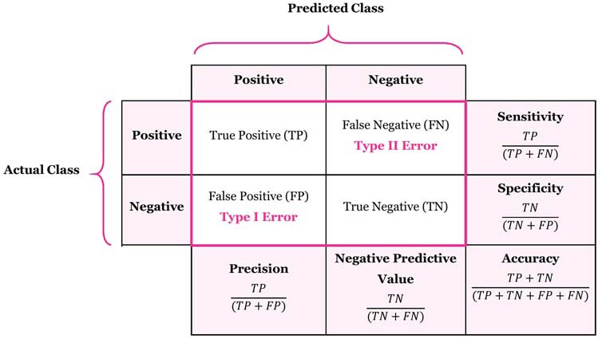

```r
predicted_probs_probit <- predict(probit_glm, data = my.df, type = "response")
tmp_out <- confusionMatrix(my.df$inlf, predicted_probs_probit, threshold = 0.5)
colnames(tmp_out) <- paste0("Actual ", colnames(tmp_out))
rownames(tmp_out) <- paste0("Predicted ", rownames(tmp_out))
# Swap order to match graphic
tmp_out<-as.data.frame(t(as.matrix(tmp_out)))
tmp_out <- tmp_out[2:1,]
tmp_out <- tmp_out[,2:1]
paste0("Probit Confusion Matrix")
tmp_out
```

'Probit Confusion Matrix'

|  | Predicted 1 | Predicted 0 |
| --- | --- | --- |
| Actual 1 | 348 | 80 |
| Actual 0 | 120 | 205 |

```r
predicted_probs_logit <- predict(logit_glm, data = my.df, type = "response")
tmp_out <- confusionMatrix(my.df$inlf, predicted_probs_logit, threshold = 0.5)
colnames(tmp_out) <- paste0("Actual ", colnames(tmp_out))
rownames(tmp_out) <- paste0("Predicted ", rownames(tmp_out))
# Swap order to match graphic
tmp_out<-as.data.frame(t(as.matrix(tmp_out)))
tmp_out <- tmp_out[2:1,]
tmp_out <- tmp_out[,2:1]
paste0("Logit Confusion Matrix")
tmp_out
```

'Logit Confusion Matrix'

|  | Predicted 1 | Predicted 0 |
| --- | --- | --- |
| Actual 1 | 347 | 81 |
| Actual 0 | 118 | 207 |

With the logit model, we see that:

- We have correctly predicted that 347 women will return to the labor force.
- Furthermore, we have correctly predicted that 207 women will not return to the labor force.

On the other hand:

- We have incorrectly predicted that 118 women will return to the labor force (they actually did not return);
- We have incorrectly predicted that 81 women will not return to the labor force (they actually did return);

```r
print(sensitivity(my.df$inlf, predicted_probs_logit, threshold = 0.5))
```

```
[1] 0.8107477
```

```r
print(specificity(my.df$inlf, predicted_probs_logit, threshold = 0.5))
```

```
[1] 0.6369231
```

```r
print(precision(my.df$inlf, predicted_probs_logit, threshold = 0.5))
```

```
[1] 0.7462366
```

```r
# Misclassification error: 1 - Accuracy
print(misClassError(my.df$inlf, predicted_probs_logit, threshold = 0.5))
```

```
[1] 0.2643
```

```r
# Accuracy
print(1 - misClassError(my.df$inlf, predicted_probs_logit, threshold = 0.5))
```

```
[1] 0.7357
```

### Receiver Operating Characteristics (ROC) Curve

The Receiver Operating Characteristics (ROC) Curve ([Wiki](https://en.wikipedia.org/wiki/Receiver_operating_characteristic)) traces the percentage of true positives accurately predicted by a given logit model as the prediction probability cutoff is lowered from 1 to 0 . ROC summarizes the model's performance by evaluating the trade-offs between true positive rate (sensitivity) and false positive rate (1- specificity).

- The TPR defines how many correct positive results occur among all positive samples available during the test.
- The FPR defines how many incorrect positive results occur among all negative samples available during the test.
- Each point on the ROC curve represents TPR and FRP from a confusion matrix for a given cutoff point value;
- Usually various cutoff points are taken from an interval: $\theta=0.01,0.02, \ldots, 0.99$. The resulting points form the so called ROC curve
- For a good model, as the cutoff is lowered, the curve should rise steeply, indicating that the TPR (Y-Axis) increases faster than the FPR (X-Axis) as the cutoff score decreases.

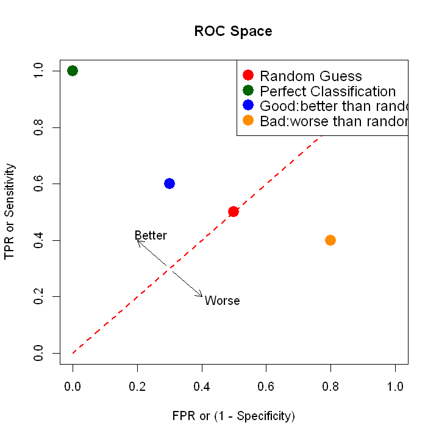

```r
plot(seq(0, 1, length.out = 100), seq(0, 1, length.out = 100),
     lty = 2, col = "red", type = "l", lwd = 2,
     xlab = "FPR or (1 - Specificity)", ylab = "TPR or Sensitivity", main = "ROC Space")
points(0, 1, pch = 19, col = "darkgreen", cex = 2)
points(0.5, 0.5, pch = 19, col = "red", cex = 2)
points(0.3, 0.6, pch = 19, col = "blue", cex = 2)
points(0.8, 0.4, pch = 19, col = "darkorange", cex = 2)
arrows(x0 = c(0.29, 0.31), y0 = c(0.31, 0.29),
       x1 = c(0.2, 0.4), y1 = c(0.4, 0.2), code = 2, col = 1, length = 0.1) # adding arrows
text(x = c(0.19, 0.41), y= c(0.42, 0.19), 0, labels = c("Better", "Worse"), cex = 1)
#
legend("topright",
       legend = c("Random Guess", "Perfect Classification",
                  "Good:better than random", "Bad:worse than random"),
       pch = c(19, 19, 19, 19), col = c("red", "darkgreen", "blue", "darkorange"),
       cex = 1.2, pt.cex = 2)
```

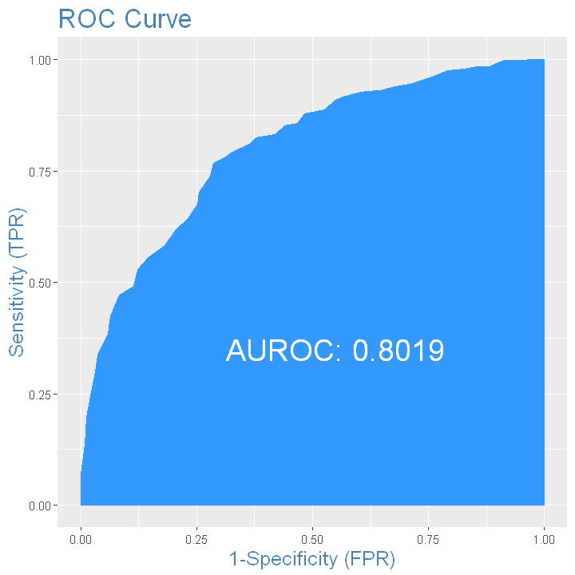

```r
plotROC(my.df$inlf, predicted_probs_logit)
```

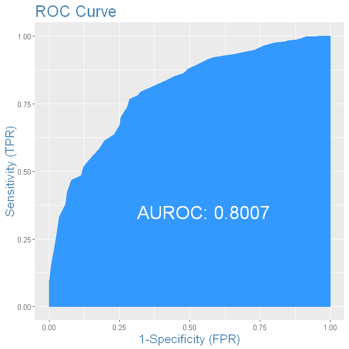

```r
plotROC(my.df$inlf, predicted_probs_probit)
```

An ROC curve demonstrates several things:

- It shows the trade-off between sensitivity and specificity (any increase in sensitivity will be accompanied by a decrease in specificity).Recall our discussion of hypothesis tests and Type 1 and Type 2 errors from [last semester](https://ciresar.github.io/NYU/Lab_7/hypothesis_testing_intro.html);
- The closer the curve follows the left-hand border and then the top border of the ROC space, the more accurate the test.
- The closer the curve comes to the 45-degree diagonal of the ROC space, the less accurate the test;

A problem with the ROC AUC is that reducing the ROC Curve to a single number ignores the fact that it is about the trade-offs between the different performance points plotted and not the performance of an individual system.